# Этап 1

Научная проблема проекта “Неравновестная агрегация, фракталы”

Апареев Д. А.,

Демидович Н. М.,

Игнатенкова В. Н.

Российский университет дружбы народов, Москва, Россия

22 марта 2025

# Информация

## Состав исследовательской команды

Студенты группы НКНбд-01-22:

- Апареев Д. А.,
- Демидович Н. М.,
- Игнатенкова В. Н.

## Состав исследовательской команды

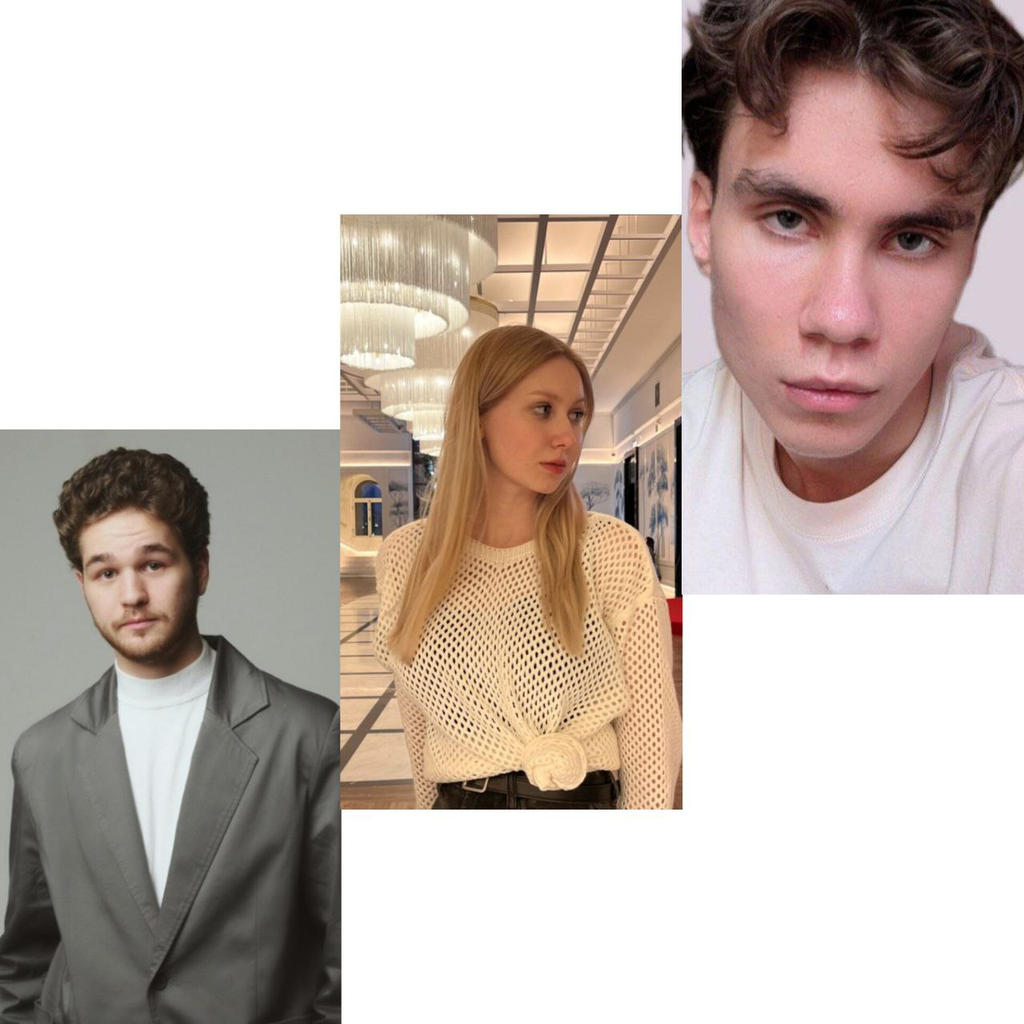

# Вводная часть

## Эпиграф

> “Перенос чужих выводов в терминологически более изящную форму редко расценивается как научное достижение.“  
> Бенуа Б. Мандельброт

## Актуальность

Существуют разнообразные физические процессы, основная черта которых — неравновесная агрегация:

- образование частиц сажи
- выращивание кристаллов соли
- распространение воды в нефти

## Объект и предмет исследования

- Модели неравновесной агрегации
- Фрактальная размерность
- График зависимости числа частиц в кластере от радиуса гирации

## Цели и задачи

**Цель работы**

Построить модели неравновесной агрегации и выявить их особенности.

**Задачи**

- Построить модель агрегации, ограниченной диффузией
- Построить модель баллистической агрегации
- Найти размерность, получившихся кластеров
- Построить график зависимости числа частиц в кластере от радиуса гирации

# Теоретическое описание задачи

## Фрактальная размерность

*N*(*ϵ*) - количество квадратов, необходимое для покрытия фрактала, *ϵ* - сторона квадрата, *d* - переменная.

$$N(\epsilon) \sim \dfrac{1}{\epsilon^d}$$

$$\ln{N(\epsilon)} \sim \ln{\dfrac{1}{\epsilon^d}} =
\ln{\dfrac{1}{\epsilon}}^d = d \ln{\dfrac{1}{\epsilon}}$$

## Фрактальная размерность

$$d = \lim_{\epsilon \rightarrow
0}(\dfrac{ln(N(\epsilon))}{ln(\dfrac{1}{\epsilon})})$$

где *D* – фрактальная размерность, *N*(*ϵ*) – число частиц на расстоянии меньшем чем *R*, *R* – радиус

## Агрегация, ограниченная диффузией

**Агрегация, ограниченная диффузией (diffusion-limited aggregation, DLA)** — первая модель агрегации, представляющая собой шумный рост, ограниченный диффузией.

## Агрегация, ограниченная диффузией

У получающегося кластера может быть много различных форм, преимущественно зависящих от трёх факторов:

- положение центра агрегации;
- начальное положение движущейся частицы;
- алгоритм моделирования движения.

## Агрегация, ограниченная химический реакцией

**Агрегация, ограниченная химический реакцией (reaction limited aggregation, RLA)** — модель агрегации, рассматривающая процессы, кинетика которых определяется химическим взаимодействием.

## Баллистическая агрегация

**Баллистическая модель (Ballistic particle-cluster aggregation, BPCA)** — модель агрегации, в которой зародившаяся частица, двигается по прямой в случайно выбранном направлении до столкновения с частицей и последующей агрегацией.

## Кластер-кластерная агрегация

**Кластер-кластерная агрегации, ограниченной диффузией (diffusion-limited cluster aggregation, DLCA)** — модель агрегации, при которой располагется несколько начальных частиц.

# Заключение

## Выводы

Во время выполнения первого этапа группового проекта мы сделали теоретическое описание моделей неравновесной агрегации и определили задачи дальнейшего исследования.

## Список литературы

1. Медведев Д.А. и др. Моделирование физических процессов и явлений на ПК: Учеб. пособие. Новосибирск: Новосиб. гос. ун-т, 2010. 101 с.
2. Sander L.M. Diffusion-limited aggregation: A kinetic critical phenomenon? Contemporary Physics, 2000.
3. Тыртышников А.Ю. и др. Сравнение алгоритмов DLA и RLA при моделировании пористых структур. НИИ «Центрпрограммсистем», 2017. 244 с.